# PCIT-CoS-Waitlist RCT Paper 1: PSI Total

Nancy Briggs

2024-06-13

### PSI Total

Output run on 2024-06-13

This output is run on the data in “PSI-SF data_recoded 12.6.24.sav”

Variables: PSI_total_T1 PSI_total_T2 PSI_total_T3

#### Descriptives

| group | time | n | mean | sd | median | min | max |
| --- | --- | --- | --- | --- | --- | --- | --- |
| 1 | 1 | 22 | 91.521 | 20.732 | 90.200 | 56.836 | 127.927 |
| 1 | 2 | 23 | 80.964 | 19.586 | 76.745 | 54.782 | 137.636 |
| 1 | 3 | 18 | 84.094 | 24.049 | 78.400 | 51.236 | 152.564 |
| 2 | 1 | 22 | 99.453 | 18.577 | 95.318 | 62.582 | 143.018 |
| 2 | 2 | 12 | 92.392 | 21.127 | 85.073 | 59.691 | 125.927 |
| 2 | 3 | 4 | 82.232 | 21.056 | 83.318 | 58.582 | 103.709 |
| 3 | 1 | 19 | 87.741 | 20.830 | 86.891 | 48.345 | 113.000 |
| 3 | 2 | 20 | 85.908 | 18.319 | 92.100 | 51.709 | 112.455 |
| 3 | 3 | 0 | NaN | NA | NA | Inf | -Inf |

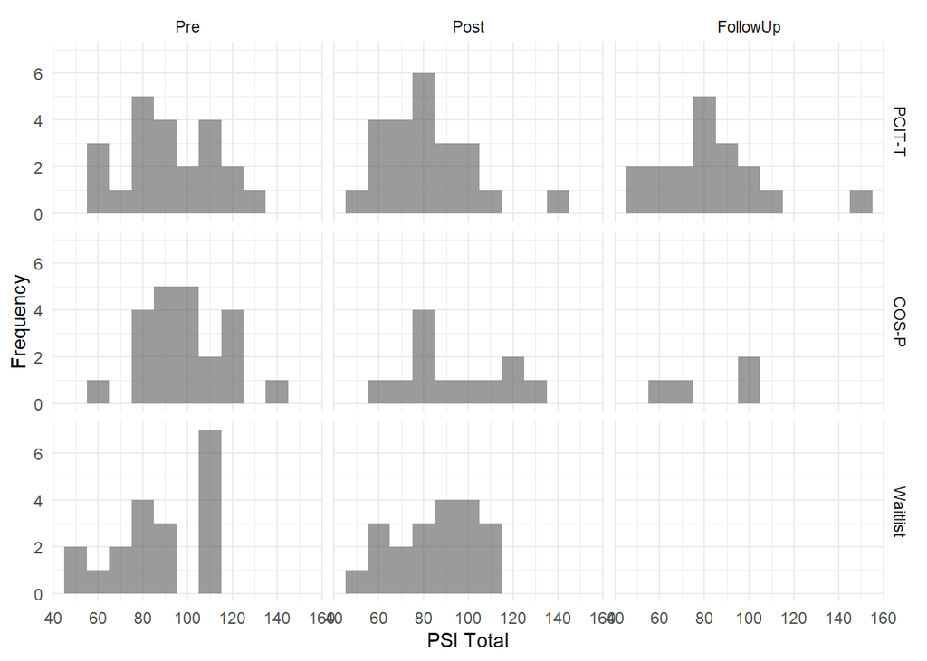

#### Model & Results

A linear mixed model with random effect for individual and fixed effects of group, time and the interaction was run. Estimated marginal means were obtained, and contrasts specified to test Hypothesis 1 and Hypothesis 2.

```
## fixed-effect model matrix is rank deficient so dropping 1 column / coefficient
```

```
## refitting model(s) with ML (instead of REML)
```

|  | Effect | npar | AIC | BIC | logLik | deviance | Chisq | Df | Pr(>Chisq) |
| --- | --- | --- | --- | --- | --- | --- | --- | --- | --- |
| result0 | Intercept | 3 | 1192.962 | 1201.787 | -593.481 | 1186.962 | NA | NA | NA |
| result1 | Group | 5 | 1194.215 | 1208.923 | -592.107 | 1184.215 | 2.748 | 2 | 0.253 |
| result2 | Time | 7 | 1183.131 | 1203.723 | -584.566 | 1169.131 | 15.083 | 2 | 0.001 |
| result3 | Group*Time | 10 | 1183.376 | 1212.793 | -581.688 | 1163.376 | 5.755 | 3 | 0.124 |

This is the ANOVA table for the model. p-values are likelihood ratio tests for adding the new term to the model just before. A p-value <0.05 indicates that adding that term results in better model fit. The most important p-value is the interaction p-value. Here, there is no evidence that the pattern of change over time is different among the groups (p=0.124).

```r
summary(result3)
```

```
## Linear mixed model fit by REML. t-tests use Satterthwaite's method [
## lmerModLmerTest]
## Formula: outcome ~ group * time + (1 | id)
##    Data: dat
##
## REML criterion at convergence: 1128.5
##
## Scaled residuals:
##      Min       1Q   Median       3Q      Max
## -1.75564 -0.47439 -0.05432  0.40380  1.66049
##
## Random effects:
##  Groups   Name        Variance Std.Dev.
##  id       (Intercept) 342.89   18.517
##  Residual              73.49    8.572
## Number of obs: 140, groups:  id, 81
##
## Fixed effects:
##              Estimate Std. Error      df t value Pr(>|t|)
## (Intercept)    91.868      3.919 101.744  23.444  < 2e-16 ***
## group2          6.307      5.692  98.582   1.108  0.27060
## group3         -4.570      5.814 101.454  -0.786  0.43370
## time2          -9.339      2.906  60.960  -3.214  0.00210 **
## time3          -8.400      3.110  60.378  -2.701  0.00897 **
## group2:time2   -1.477      4.908  66.771  -0.301  0.76446
## group3:time2    7.576      4.274  61.564   1.773  0.08125 .
## group2:time3   -7.161      6.555  62.519  -1.092  0.27883
## ---
## Signif. codes:  0 '***' 0.001 '**' 0.01 '*' 0.05 '.' 0.1 ' ' 1
##
## Correlation of Fixed Effects:
##             (Intr) group2 group3 time2  time3  grp2:2 grp3:2
## group2      -0.688
## group3      -0.674  0.464
## time2       -0.375  0.258  0.253
## time3       -0.344  0.237  0.232  0.560
## group2:tim2  0.222 -0.326 -0.150 -0.592 -0.332
## group3:tim2  0.255 -0.175 -0.377 -0.680 -0.381  0.403
## group2:tim3  0.163 -0.233 -0.110 -0.266 -0.475  0.432  0.181
## fit warnings:
## fixed-effect model matrix is rank deficient so dropping 1 column / coefficient
```

#### Estimated Means & Change

Estimated means for each Treatment and Time are presented. In addition, within-group change between time points is presented with 95% CIs.

##### Group mean difference at each timepoint

Group Differences at Each Time Point

| Group Difference | Time | Mean | SE | t | p | adj p | Lower CL | Upper CL | Effect Size | Lower CL | Upper CL |
| --- | --- | --- | --- | --- | --- | --- | --- | --- | --- | --- | --- |
| 1 - 2 | 1 | -6.307 | 5.695 | -1.107 | 0.512 | 0.812 | -19.860 | 7.246 | -0.320 | -0.791 | 0.265 |
| 1 - 3 | 1 | 4.570 | 5.817 | 0.786 | 0.713 | 1.000 | -9.267 | 18.406 | 0.232 | -0.073 | 0.646 |
| 2 - 3 | 1 | 10.876 | 5.961 | 1.825 | 0.167 | 0.213 | -3.309 | 25.062 | 0.553 | 0.067 | 0.766 |
| 1 - 2 | 2 | -4.830 | 6.195 | -0.780 | 0.716 | 1.000 | -19.538 | 9.878 | -0.245 | -0.685 | 0.346 |
| 1 - 3 | 2 | -3.006 | 5.777 | -0.520 | 0.862 | 1.000 | -16.753 | 10.740 | -0.153 | -0.425 | 0.210 |
| 2 - 3 | 2 | 1.824 | 6.418 | 0.284 | 0.956 | 1.000 | -13.415 | 17.063 | 0.093 | -0.373 | 0.423 |
| 1 - 2 | 3 | 0.854 | 7.629 | 0.112 | 0.993 | 1.000 | -17.235 | 18.943 | 0.043 | -0.520 | 0.809 |
| 1 - 3 | 3 | NA | NA | NA | NA | NA | NA | NA | NA | NA | NA |
| 2 - 3 | 3 | NA | NA | NA | NA | NA | NA | NA | NA | NA | NA |

* Effect size scaled by pooled T1 SD  
† ES 95% Bootstrapped Percentile CI limits  
‡ If you want a positive ES (and it is calculated as negative), be sure to switch the signs and positions of the lower and upper CIs.

##### Change within each group

Within-Group Change and Effect Sizes

| Change | Group | Mean | SE | t | p | adj p | Lower CL | Upper CL | Effect Size | Lower CL | Upper CL |
| --- | --- | --- | --- | --- | --- | --- | --- | --- | --- | --- | --- |
| 1 - 2 | 1 | 9.339 | 2.915 | 3.204 | 0.006 | 0.007 | 2.335 | 16.344 | 0.474 | 0.291 | 0.739 |
| 1 - 3 | 1 | 8.400 | 3.119 | 2.693 | 0.025 | 0.028 | 0.904 | 15.896 | 0.427 | 0.092 | 0.682 |
| 2 - 3 | 1 | -0.939 | 2.830 | -0.332 | 0.941 | 1.000 | -7.753 | 5.874 | -0.048 | -0.274 | 0.113 |
| 1 - 2 | 2 | 10.816 | 3.980 | 2.717 | 0.022 | 0.025 | 1.283 | 20.349 | 0.549 | 0.126 | 0.950 |
| 1 - 3 | 2 | 15.561 | 5.793 | 2.686 | 0.025 | 0.028 | 1.653 | 29.469 | 0.791 | 0.232 | 1.358 |
| 2 - 3 | 2 | 4.745 | 5.602 | 0.847 | 0.676 | 1.000 | -8.732 | 18.222 | 0.241 | -0.484 | 0.594 |
| 1 - 2 | 3 | 1.764 | 3.144 | 0.561 | 0.841 | 1.000 | -5.788 | 9.316 | 0.090 | -0.046 | 0.329 |
| 1 - 3 | 3 | NA | NA | NA | NA | NA | NA | NA | NA | NA | NA |
| 2 - 3 | 3 | NA | NA | NA | NA | NA | NA | NA | NA | NA | NA |

* Effect size scaled by pooled T1 SD  
† ES 95% Bootstrapped Percentile CI limits  
‡ If you want a positive ES (and it is calculated as negative), be sure to switch the signs and positions of the lower and upper CIs.

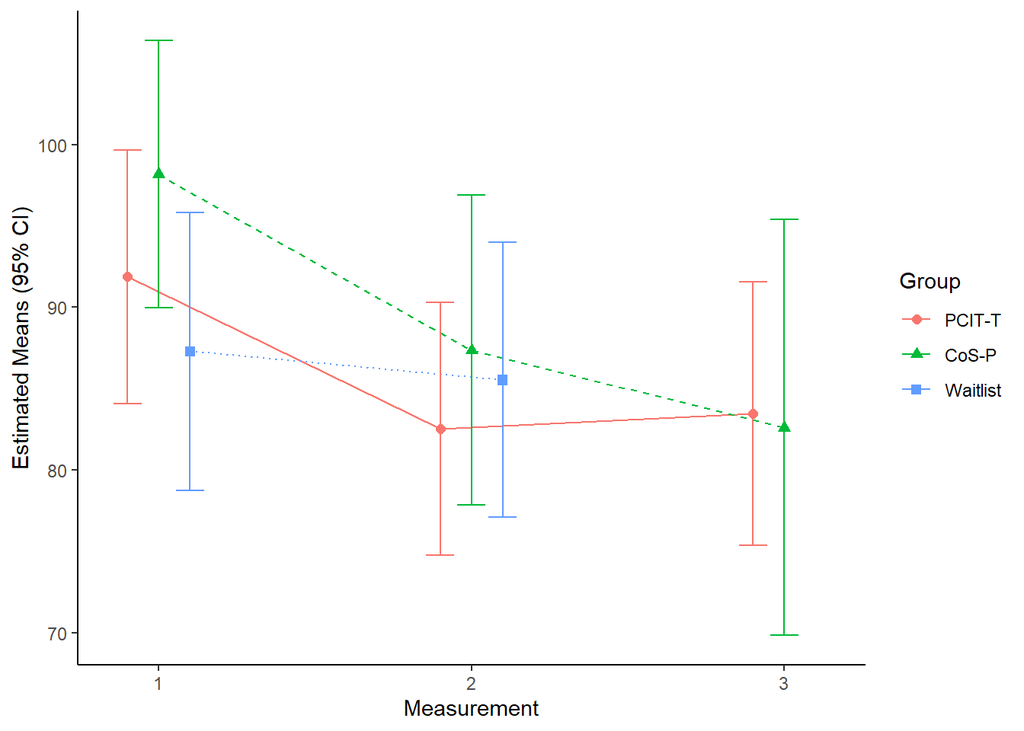

#### Hypothesis 1

We hypothesize that from baseline (‘T1’) to post-treatment/waitlist (‘T2’) there will be a gradient effect, whereby parent-child dyads who receive PCIT-T will show the greatest gains and parent-child dyads who receive no treatment will show the least gains. For the outcome, then, the null hypothesis is:

$H_0: \text {mean change}(\text{PCIT-T}) = \text {mean change}(\text{CoS-P}) = \text {mean change}(\text{Waitlist})$ $H_A: \text {mean change}(\text{PCIT-T}) > \text {mean change}(\text{CoS-P}) > \text {mean change}(\text{Waitlist})$

This is a joint hypothesis test.

First, confirming that the ordering of the means is as hypothesized:

```
## group = 1:
##  contrast estimate   SE   df t.ratio p.value
##  1 - 2       9.339 2.91 60.2   3.204  0.0061
##  1 - 3       8.400 3.12 59.6   2.693  0.0245
##  2 - 3      -0.939 2.83 55.8  -0.332  0.9411
##
## group = 2:
##  contrast estimate   SE   df t.ratio p.value
##  1 - 2      10.816 3.98 69.4   2.717  0.0224
##  1 - 3      15.561 5.79 62.4   2.686  0.0248
##  2 - 3       4.745 5.60 57.8   0.847  0.6756
##
## group = 3:
##  contrast estimate   SE   df t.ratio p.value
##  1 - 2       1.764 3.14 61.3   0.561  0.8413
##  1 - 3      nonEst   NA   NA      NA      NA
##  2 - 3      nonEst   NA   NA      NA      NA
##
## Degrees-of-freedom method: kenward-roger
## P value adjustment: tukey method for comparing a family of 3 estimates
```

| contrast | group | t1t2change | quality | p.value |
| --- | --- | --- | --- | --- |
| 1 - 2 | 1 | -9.339 | decreased t1 to t2 | 0.006 |
| 1 - 2 | 2 | -10.816 | decreased t1 to t2 | 0.022 |
| 1 - 2 | 3 | -1.764 | decreased t1 to t2 | 0.841 |

Is the ordering of change satisfied?

Greatest to least change from t1 to t2: Order not satisfied

Note that I interpreted an increase in scores as being “better”. If a decrease in scores is “better” then these change values should be interpreted in that light.

```
##   (Intercept) group2 group3 time2 time3 group2:time2 group3:time2 group2:time3
## 1           0      0      0     0     0            1            0            0
## 2           0      0      0     0     0           -1            1            0
```

```
##
##   General Linear Hypotheses
##
## Linear Hypotheses:
##        Estimate
## 1 == 0   -1.477
## 2 == 0    9.052
##
## Global Test:
##       F DF1 DF2 Pr(>F)
## 1 2.185   2 130 0.1166
```

p= 0.117. We have no evidence that there is a difference in the change over from Baseline to Post amongst the groups.

#### Hypothesis 2

##### Change from T2-T3

There will be a gradient of size of change from T2 to T3 such that the change in the PCIT-T group > the change in the CoS-P group. This isn’t really a gradient; it’s just 1 hypothesis.

First, the change in PCITT and COSP from time 2 to time 3:

```
## group = 1:
##  time emmean   SE    df lower.CL upper.CL
##  1      91.9 3.92 101.2     84.1     99.6
##  2      82.5 3.91 100.0     74.8     90.3
##  3      83.5 4.08 111.6     75.4     91.6
##
## group = 2:
##  time emmean   SE    df lower.CL upper.CL
##  1      98.2 4.13  95.1     90.0    106.4
##  2      87.4 4.81 125.1     77.8     96.9
##  3      82.6 6.44 116.1     69.8     95.4
##
## group = 3:
##  time emmean   SE    df lower.CL upper.CL
##  1      87.3 4.30 100.7     78.8     95.8
##  2      85.5 4.25  98.0     77.1     94.0
##  3    nonEst   NA    NA       NA       NA
##
## Degrees-of-freedom method: kenward-roger
## Confidence level used: 0.95
```

```
## group = 1:
##  contrast estimate   SE   df lower.CL upper.CL
##  1 - 2       9.339 2.91 60.2    2.335    16.34
##  1 - 3       8.400 3.12 59.6    0.904    15.90
##  2 - 3      -0.939 2.83 55.8   -7.753     5.87
##
## group = 2:
##  contrast estimate   SE   df lower.CL upper.CL
##  1 - 2      10.816 3.98 69.4    1.283    20.35
##  1 - 3      15.561 5.79 62.4    1.653    29.47
##  2 - 3       4.745 5.60 57.8   -8.732    18.22
##
## group = 3:
##  contrast estimate   SE   df lower.CL upper.CL
##  1 - 2       1.764 3.14 61.3   -5.788     9.32
##  1 - 3      nonEst   NA   NA       NA       NA
##  2 - 3      nonEst   NA   NA       NA       NA
##
## Degrees-of-freedom method: kenward-roger
## Confidence level used: 0.95
## Conf-level adjustment: tukey method for comparing a family of 3 estimates
```

```r
## Specify contrast matrices
# Hyp1 is 1 df test
# could use alternative="less" ir alternative="greater" in glht
hyp2   <- matrix(c(0, 0,0, 0,0, -1,0,1 ),1)
hyp2F <- glht(result3, linfct = hyp2)
summary(hyp2F)
```

```
##
##   Simultaneous Tests for General Linear Hypotheses
##
## Fit: lmer(formula = outcome ~ group * time + (1 | id), data = dat)
##
## Linear Hypotheses:
##        Estimate Std. Error z value Pr(>|z|)
## 1 == 0   -5.684      6.266  -0.907    0.364
## (Adjusted p values reported -- single-step method)
```

```r
s<-summary(hyp2F, test = Ftest())
#also see this webpage for more on contrasts https://rcompanion.org/rcompanion/h_01.html



## Extract pvaue for evidence / no evidence
evidence = ifelse(s$test$pvalue<0.05, "evidence", "no evidence")
```

Change in G1 from T2 to T3: -0.939

Change in G2 from T2 to T3: 4.745

##### Change from T1-T3

```
##
##   General Linear Hypotheses
##
## Linear Hypotheses:
##        Estimate
## 1 == 0   -7.161
##
## Global Test:
##       F DF1 DF2 Pr(>F)
## 1 1.193   1 130 0.2767
```

Change in G1 from T1 to T3: 8.4

Change in G2 from T1 to T3: 15.561

p=0.2767. We have no evidence that the change from T1 to T3 is different for G1 and G2

#### Residuals

Assumptions of the model are met.

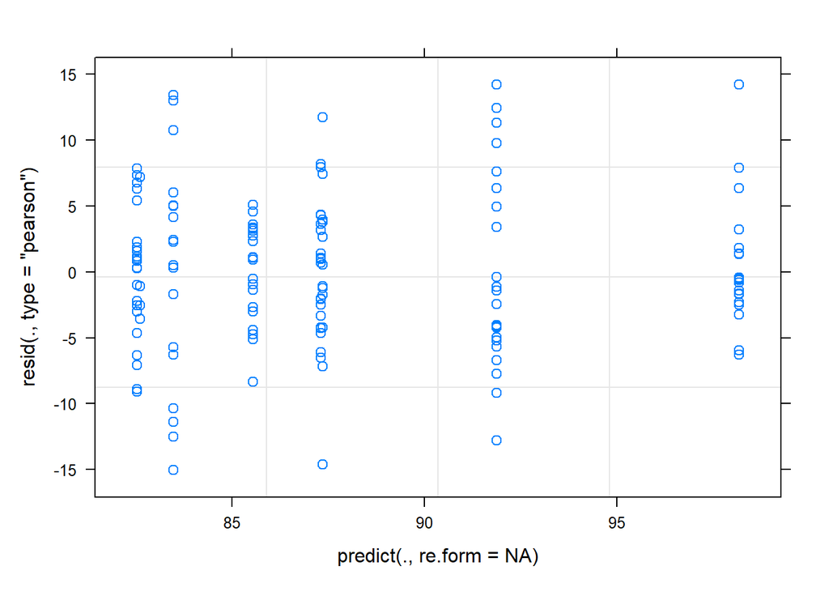

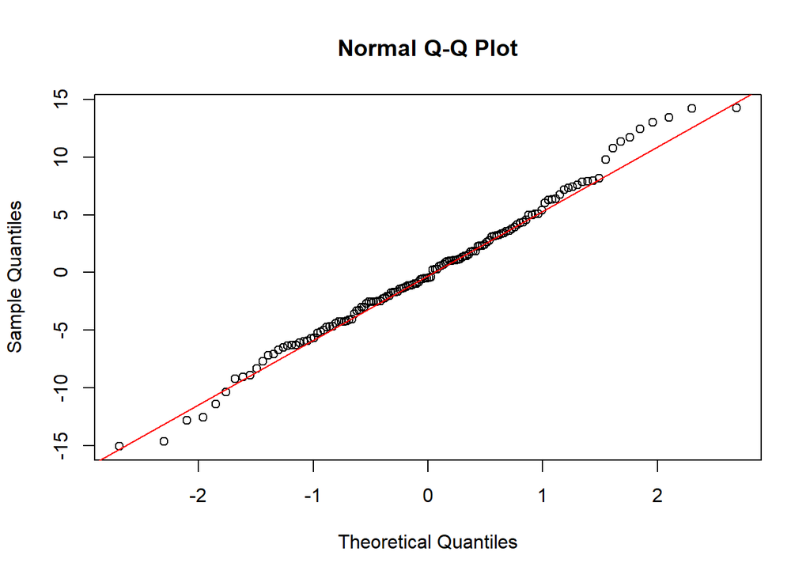

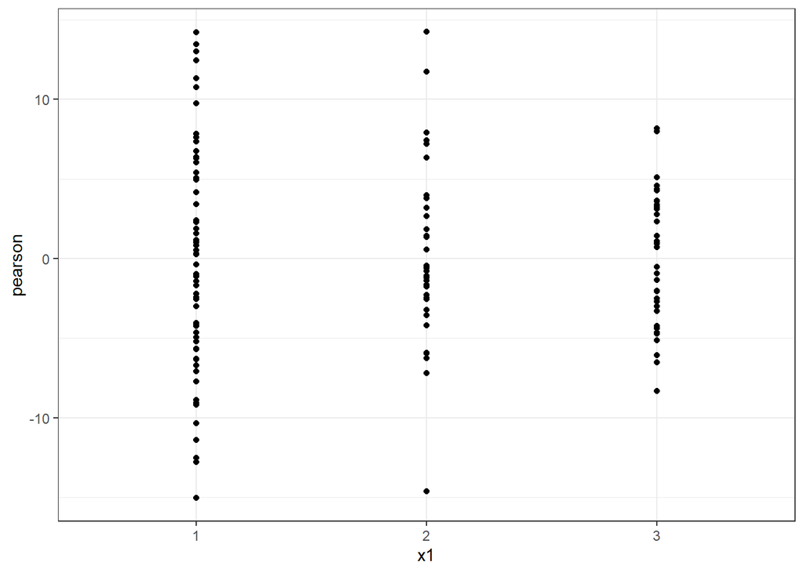

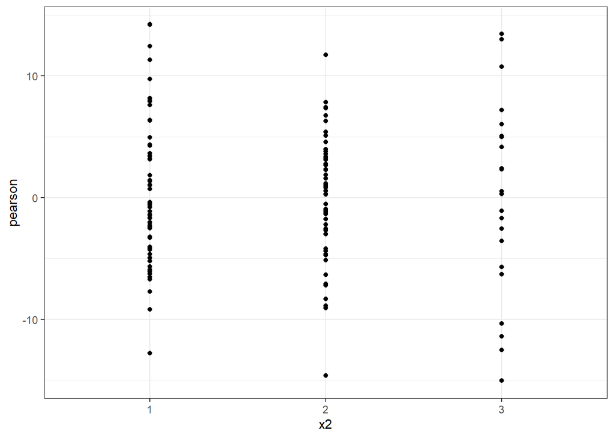

```r
rm(list = ls())
```